# Risk Factor Analysis

## Outcome Variable

**Outcome Variable:** whz

## Predictor Variables

**Intervention Variable:** impfloor

**Adjustment Set:**

unadjusted

## Stratifying Variables

The analysis was stratified on these variable(s):

- agecat
- studyid
- country

## Data Summary

| agecat | studyid | country | impfloor | n_cell | n |
| --- | --- | --- | --- | --- | --- |
| Birth | ki0047075b-MAL-ED | BANGLADESH | 1 | 205 | 222 |
| Birth | ki0047075b-MAL-ED | BANGLADESH | 0 | 17 | 222 |
| Birth | ki0047075b-MAL-ED | BRAZIL | 1 | 165 | 167 |
| Birth | ki0047075b-MAL-ED | BRAZIL | 0 | 2 | 167 |
| Birth | ki0047075b-MAL-ED | INDIA | 1 | 178 | 188 |
| Birth | ki0047075b-MAL-ED | INDIA | 0 | 10 | 188 |
| Birth | ki0047075b-MAL-ED | NEPAL | 1 | 64 | 159 |
| Birth | ki0047075b-MAL-ED | NEPAL | 0 | 95 | 159 |
| Birth | ki0047075b-MAL-ED | PERU | 1 | 54 | 252 |
| Birth | ki0047075b-MAL-ED | PERU | 0 | 198 | 252 |
| Birth | ki0047075b-MAL-ED | SOUTH AFRICA | 1 | 196 | 216 |
| Birth | ki0047075b-MAL-ED | SOUTH AFRICA | 0 | 20 | 216 |
| Birth | ki0047075b-MAL-ED | TANZANIA, UNITED REPUBLIC OF | 1 | 7 | 113 |
| Birth | ki0047075b-MAL-ED | TANZANIA, UNITED REPUBLIC OF | 0 | 106 | 113 |
| Birth | ki1000108-CMC-V-BCS-2002 | INDIA | 1 | 71 | 71 |
| Birth | ki1000108-CMC-V-BCS-2002 | INDIA | 0 | 0 | 71 |
| Birth | ki1000108-IRC | INDIA | 1 | 253 | 253 |
| Birth | ki1000108-IRC | INDIA | 0 | 0 | 253 |
| Birth | ki1017093-NIH-Birth | BANGLADESH | 1 | 24 | 28 |
| Birth | ki1017093-NIH-Birth | BANGLADESH | 0 | 4 | 28 |
| Birth | ki1017093c-NIH-Crypto | BANGLADESH | 1 | 18 | 23 |
| Birth | ki1017093c-NIH-Crypto | BANGLADESH | 0 | 5 | 23 |
| Birth | ki1114097-CONTENT | PERU | 1 | 2 | 2 |
| Birth | ki1114097-CONTENT | PERU | 0 | 0 | 2 |
| Birth | kiGH5241-JiVitA-3 | BANGLADESH | 1 | 925 | 15666 |
| Birth | kiGH5241-JiVitA-3 | BANGLADESH | 0 | 14741 | 15666 |
| Birth | kiGH5241-JiVitA-4 | BANGLADESH | 1 | 58 | 683 |
| Birth | kiGH5241-JiVitA-4 | BANGLADESH | 0 | 625 | 683 |
| 6 months | ki0047075b-MAL-ED | BANGLADESH | 1 | 221 | 240 |
| 6 months | ki0047075b-MAL-ED | BANGLADESH | 0 | 19 | 240 |

[output cut: 62 more lines]

The following strata were considered:

- agecat: 24 months, studyid: ki0047075b-MAL-ED, country: BANGLADESH
- agecat: 24 months, studyid: ki0047075b-MAL-ED, country: BRAZIL
- agecat: 24 months, studyid: ki0047075b-MAL-ED, country: INDIA
- agecat: 24 months, studyid: ki0047075b-MAL-ED, country: NEPAL
- agecat: 24 months, studyid: ki0047075b-MAL-ED, country: PERU
- agecat: 24 months, studyid: ki0047075b-MAL-ED, country: SOUTH AFRICA
- agecat: 24 months, studyid: ki0047075b-MAL-ED, country: TANZANIA, UNITED REPUBLIC OF
- agecat: 24 months, studyid: ki1000108-CMC-V-BCS-2002, country: INDIA
- agecat: 24 months, studyid: ki1000108-IRC, country: INDIA
- agecat: 24 months, studyid: ki1017093-NIH-Birth, country: BANGLADESH
- agecat: 24 months, studyid: ki1017093b-PROVIDE, country: BANGLADESH
- agecat: 24 months, studyid: ki1017093c-NIH-Crypto, country: BANGLADESH
- agecat: 24 months, studyid: ki1113344-GMS-Nepal, country: NEPAL
- agecat: 24 months, studyid: ki1114097-CONTENT, country: PERU
- agecat: 24 months, studyid: kiGH5241-JiVitA-3, country: BANGLADESH
- agecat: 24 months, studyid: kiGH5241-JiVitA-4, country: BANGLADESH
- agecat: 6 months, studyid: ki0047075b-MAL-ED, country: BANGLADESH
- agecat: 6 months, studyid: ki0047075b-MAL-ED, country: BRAZIL
- agecat: 6 months, studyid: ki0047075b-MAL-ED, country: INDIA
- agecat: 6 months, studyid: ki0047075b-MAL-ED, country: NEPAL
- agecat: 6 months, studyid: ki0047075b-MAL-ED, country: PERU
- agecat: 6 months, studyid: ki0047075b-MAL-ED, country: SOUTH AFRICA
- agecat: 6 months, studyid: ki0047075b-MAL-ED, country: TANZANIA, UNITED REPUBLIC OF
- agecat: 6 months, studyid: ki1000108-CMC-V-BCS-2002, country: INDIA
- agecat: 6 months, studyid: ki1000108-IRC, country: INDIA
- agecat: 6 months, studyid: ki1017093-NIH-Birth, country: BANGLADESH
- agecat: 6 months, studyid: ki1017093b-PROVIDE, country: BANGLADESH
- agecat: 6 months, studyid: ki1017093c-NIH-Crypto, country: BANGLADESH
- agecat: 6 months, studyid: ki1113344-GMS-Nepal, country: NEPAL
- agecat: 6 months, studyid: ki1114097-CONTENT, country: PERU
- agecat: 6 months, studyid: kiGH5241-JiVitA-3, country: BANGLADESH
- agecat: 6 months, studyid: kiGH5241-JiVitA-4, country: BANGLADESH
- agecat: Birth, studyid: ki0047075b-MAL-ED, country: BANGLADESH
- agecat: Birth, studyid: ki0047075b-MAL-ED, country: BRAZIL
- agecat: Birth, studyid: ki0047075b-MAL-ED, country: INDIA
- agecat: Birth, studyid: ki0047075b-MAL-ED, country: NEPAL
- agecat: Birth, studyid: ki0047075b-MAL-ED, country: PERU
- agecat: Birth, studyid: ki0047075b-MAL-ED, country: SOUTH AFRICA
- agecat: Birth, studyid: ki0047075b-MAL-ED, country: TANZANIA, UNITED REPUBLIC OF
- agecat: Birth, studyid: ki1000108-CMC-V-BCS-2002, country: INDIA
- agecat: Birth, studyid: ki1000108-IRC, country: INDIA
- agecat: Birth, studyid: ki1017093-NIH-Birth, country: BANGLADESH
- agecat: Birth, studyid: ki1017093c-NIH-Crypto, country: BANGLADESH
- agecat: Birth, studyid: ki1114097-CONTENT, country: PERU
- agecat: Birth, studyid: kiGH5241-JiVitA-3, country: BANGLADESH
- agecat: Birth, studyid: kiGH5241-JiVitA-4, country: BANGLADESH

### Dropped Strata

Some strata were dropped due to rare outcomes:

- agecat: Birth, studyid: ki0047075b-MAL-ED, country: BRAZIL
- agecat: Birth, studyid: ki1000108-CMC-V-BCS-2002, country: INDIA
- agecat: Birth, studyid: ki1000108-IRC, country: INDIA
- agecat: Birth, studyid: ki1017093-NIH-Birth, country: BANGLADESH
- agecat: Birth, studyid: ki1114097-CONTENT, country: PERU
- agecat: 6 months, studyid: ki0047075b-MAL-ED, country: BRAZIL
- agecat: 6 months, studyid: ki1000108-CMC-V-BCS-2002, country: INDIA
- agecat: 6 months, studyid: ki1000108-IRC, country: INDIA
- agecat: 24 months, studyid: ki0047075b-MAL-ED, country: BRAZIL
- agecat: 24 months, studyid: ki1000108-CMC-V-BCS-2002, country: INDIA
- agecat: 24 months, studyid: ki1000108-IRC, country: INDIA

## Methods Detail

We’re interested in the causal parameters $E[Y_a]$ for all values of $a \in \mathcal{A}$. These parameters represent the mean outcome if, possibly contrary to fact, we intervened to set all units to have $A=a$. Under the randomization and positivity assumptions, these are identified by the statistical parameters $\psi_a=E_W[E_{Y|A,W}(Y|A=a,W)]$. In addition, we’re interested in the mean of $Y$, $E[Y]$ under no intervention (the observed mean). We will estimate these parameters by using SuperLearner to fit the relevant likelihood factors – $E_{Y|A,W}(Y|A=a,W)$ and $p(A=a|W)$, and then updating our likelihood fit using a joint TMLE.

For unadjusted analyses ($W=\{\}$), initial likelihoods were estimated using Lrnr_glm to estimate the simple $E(Y|A)$ and Lrnr_mean to estimate $p(A)$. For adjusted analyses, a small library containing Lrnr_glmnet, Lrnr_xgboost, and Lrnr_mean was used.

Having estimated these parameters, we will then use the delta method to estimate relative risks and attributable risks relative to a prespecified baseline level of $A$.

# Results Detail

## Results Plots

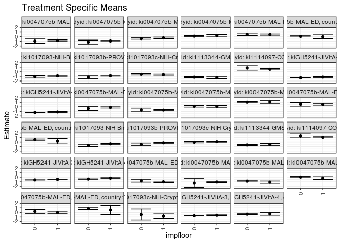

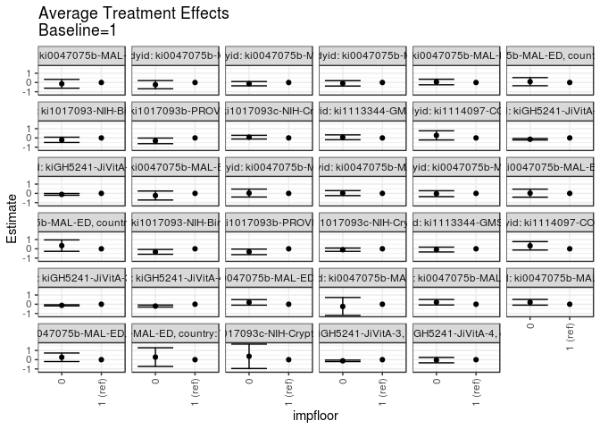

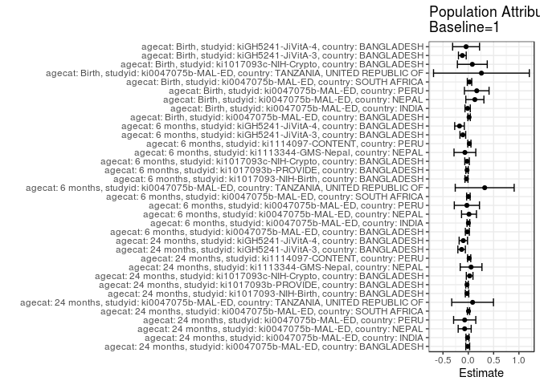

## Results Table

### Parameter: TSM

| agecat | studyid | country | intervention_level | baseline_level | estimate | ci_lower | ci_upper |
| --- | --- | --- | --- | --- | --- | --- | --- |
| Birth | ki0047075b-MAL-ED | BANGLADESH | 1 | NA | -1.0056585 | -1.1565036 | -0.8548135 |
| Birth | ki0047075b-MAL-ED | BANGLADESH | 0 | NA | -0.8041176 | -1.0636460 | -0.5445893 |
| Birth | ki0047075b-MAL-ED | INDIA | 1 | NA | -1.0408989 | -1.1815195 | -0.9002783 |
| Birth | ki0047075b-MAL-ED | INDIA | 0 | NA | -1.2810000 | -2.2424635 | -0.3195365 |
| Birth | ki0047075b-MAL-ED | NEPAL | 1 | NA | -1.0660938 | -1.3033826 | -0.8288049 |
| Birth | ki0047075b-MAL-ED | NEPAL | 0 | NA | -0.8491579 | -1.0287407 | -0.6695751 |
| Birth | ki0047075b-MAL-ED | PERU | 1 | NA | -0.2053704 | -0.4882734 | 0.0775326 |
| Birth | ki0047075b-MAL-ED | PERU | 0 | NA | 0.0070202 | -0.1176747 | 0.1317151 |
| Birth | ki0047075b-MAL-ED | SOUTH AFRICA | 1 | NA | -0.0313265 | -0.1970677 | 0.1344146 |
| Birth | ki0047075b-MAL-ED | SOUTH AFRICA | 0 | NA | 0.2280000 | -0.2015347 | 0.6575347 |
| Birth | ki0047075b-MAL-ED | TANZANIA, UNITED REPUBLIC OF | 1 | NA | 0.5485714 | -0.4383071 | 1.5354500 |
| Birth | ki0047075b-MAL-ED | TANZANIA, UNITED REPUBLIC OF | 0 | NA | 0.8251887 | 0.6170513 | 1.0333260 |
| Birth | ki1017093c-NIH-Crypto | BANGLADESH | 1 | NA | -0.8305556 | -1.3428871 | -0.3182240 |
| Birth | ki1017093c-NIH-Crypto | BANGLADESH | 0 | NA | -0.4640000 | -1.6852927 | 0.7572927 |
| Birth | kiGH5241-JiVitA-3 | BANGLADESH | 1 | NA | -0.6058486 | -0.6852944 | -0.5264029 |
| Birth | kiGH5241-JiVitA-3 | BANGLADESH | 0 | NA | -0.7309036 | -0.7512122 | -0.7105950 |
| Birth | kiGH5241-JiVitA-4 | BANGLADESH | 1 | NA | -0.3244828 | -0.5998485 | -0.0491170 |
| Birth | kiGH5241-JiVitA-4 | BANGLADESH | 0 | NA | -0.3723840 | -0.4574385 | -0.2873295 |
| 6 months | ki0047075b-MAL-ED | BANGLADESH | 1 | NA | -0.1169947 | -0.2512921 | 0.0173027 |
| 6 months | ki0047075b-MAL-ED | BANGLADESH | 0 | NA | -0.3502632 | -0.8176916 | 0.1171653 |
| 6 months | ki0047075b-MAL-ED | INDIA | 1 | NA | -0.7077424 | -0.8389725 | -0.5765124 |
| 6 months | ki0047075b-MAL-ED | INDIA | 0 | NA | -0.6752222 | -1.0830695 | -0.2673750 |
| 6 months | ki0047075b-MAL-ED | NEPAL | 1 | NA | 0.1146926 | -0.0804026 | 0.3097878 |
| 6 months | ki0047075b-MAL-ED | NEPAL | 0 | NA | 0.1400265 | -0.0434586 | 0.3235115 |
| 6 months | ki0047075b-MAL-ED | PERU | 1 | NA | 1.0806897 | 0.7945562 | 1.3668231 |
| 6 months | ki0047075b-MAL-ED | PERU | 0 | NA | 1.0450943 | 0.9097650 | 1.1804237 |
| 6 months | ki0047075b-MAL-ED | SOUTH AFRICA | 1 | NA | 0.5385226 | 0.3750979 | 0.7019472 |
| 6 months | ki0047075b-MAL-ED | SOUTH AFRICA | 0 | NA | 0.5610000 | 0.1590909 | 0.9629091 |
| 6 months | ki0047075b-MAL-ED | TANZANIA, UNITED REPUBLIC OF | 1 | NA | 0.1921429 | -0.4103635 | 0.7946492 |
| 6 months | ki0047075b-MAL-ED | TANZANIA, UNITED REPUBLIC OF | 0 | NA | 0.5358947 | 0.4024112 | 0.6693782 |
| 6 months | ki1017093-NIH-Birth | BANGLADESH | 1 | NA | -0.4002433 | -0.4954857 | -0.3050010 |
| 6 months | ki1017093-NIH-Birth | BANGLADESH | 0 | NA | -0.7313793 | -0.9725395 | -0.4902191 |
| 6 months | ki1017093b-PROVIDE | BANGLADESH | 1 | NA | -0.1840291 | -0.2719730 | -0.0960851 |
| 6 months | ki1017093b-PROVIDE | BANGLADESH | 0 | NA | -0.5134884 | -0.7991926 | -0.2277841 |
| 6 months | ki1017093c-NIH-Crypto | BANGLADESH | 1 | NA | 0.0543017 | -0.0374388 | 0.1460422 |
| 6 months | ki1017093c-NIH-Crypto | BANGLADESH | 0 | NA | -0.0442697 | -0.1984281 | 0.1098888 |
| 6 months | ki1113344-GMS-Nepal | NEPAL | 1 | NA | -0.5598291 | -0.7980139 | -0.3216442 |
| 6 months | ki1113344-GMS-Nepal | NEPAL | 0 | NA | -0.6411065 | -0.7484777 | -0.5337353 |
| 6 months | ki1114097-CONTENT | PERU | 1 | NA | 1.0474718 | 0.9267658 | 1.1681778 |
| 6 months | ki1114097-CONTENT | PERU | 0 | NA | 1.3693571 | 0.9298138 | 1.8089004 |
| 6 months | kiGH5241-JiVitA-3 | BANGLADESH | 1 | NA | -0.4845694 | -0.5439941 | -0.4251446 |
| 6 months | kiGH5241-JiVitA-3 | BANGLADESH | 0 | NA | -0.6030203 | -0.6235010 | -0.5825397 |
| 6 months | kiGH5241-JiVitA-4 | BANGLADESH | 1 | NA | -0.2166102 | -0.3160318 | -0.1171885 |
| 6 months | kiGH5241-JiVitA-4 | BANGLADESH | 0 | NA | -0.4143036 | -0.4546038 | -0.3740034 |
| 24 months | ki0047075b-MAL-ED | BANGLADESH | 1 | NA | -0.8094615 | -0.9359410 | -0.6829821 |
| 24 months | ki0047075b-MAL-ED | BANGLADESH | 0 | NA | -0.9511765 | -1.4088437 | -0.4935092 |
| 24 months | ki0047075b-MAL-ED | INDIA | 1 | NA | -0.9366274 | -1.0561028 | -0.8171519 |
| 24 months | ki0047075b-MAL-ED | INDIA | 0 | NA | -1.1736667 | -1.6019136 | -0.7454198 |
| 24 months | ki0047075b-MAL-ED | NEPAL | 1 | NA | -0.2774490 | -0.4507195 | -0.1041785 |
| 24 months | ki0047075b-MAL-ED | NEPAL | 0 | NA | -0.4055285 | -0.5571555 | -0.2539015 |
| 24 months | ki0047075b-MAL-ED | PERU | 1 | NA | 0.1908163 | -0.0654759 | 0.4471085 |
| 24 months | ki0047075b-MAL-ED | PERU | 0 | NA | 0.0970395 | -0.0381353 | 0.2322143 |
| 24 months | ki0047075b-MAL-ED | SOUTH AFRICA | 1 | NA | 0.4226136 | 0.2955235 | 0.5497038 |
| 24 months | ki0047075b-MAL-ED | SOUTH AFRICA | 0 | NA | 0.4766667 | 0.2087665 | 0.7445668 |
| 24 months | ki0047075b-MAL-ED | TANZANIA, UNITED REPUBLIC OF | 1 | NA | -0.0420833 | -0.4589904 | 0.3748237 |
| 24 months | ki0047075b-MAL-ED | TANZANIA, UNITED REPUBLIC OF | 0 | NA | 0.0481000 | -0.0825346 | 0.1787346 |
| 24 months | ki1017093-NIH-Birth | BANGLADESH | 1 | NA | -0.8863719 | -0.9916999 | -0.7810439 |
| 24 months | ki1017093-NIH-Birth | BANGLADESH | 0 | NA | -1.0934000 | -1.3612968 | -0.8255032 |
| 24 months | ki1017093b-PROVIDE | BANGLADESH | 1 | NA | -0.8624060 | -0.9485916 | -0.7762204 |
| 24 months | ki1017093b-PROVIDE | BANGLADESH | 0 | NA | -1.1832609 | -1.4736073 | -0.8929144 |
| 24 months | ki1017093c-NIH-Crypto | BANGLADESH | 1 | NA | -0.6369653 | -0.7526951 | -0.5212356 |
| 24 months | ki1017093c-NIH-Crypto | BANGLADESH | 0 | NA | -0.5555357 | -0.7197739 | -0.3912975 |
| 24 months | ki1113344-GMS-Nepal | NEPAL | 1 | NA | -1.2465741 | -1.4849736 | -1.0081745 |
| 24 months | ki1113344-GMS-Nepal | NEPAL | 0 | NA | -1.1787874 | -1.2926824 | -1.0648924 |
| 24 months | ki1114097-CONTENT | PERU | 1 | NA | 0.5500325 | 0.4082896 | 0.6917753 |
| 24 months | ki1114097-CONTENT | PERU | 0 | NA | 0.8255000 | 0.3508595 | 1.3001405 |
| 24 months | kiGH5241-JiVitA-3 | BANGLADESH | 1 | NA | -1.1652530 | -1.2449551 | -1.0855508 |
| 24 months | kiGH5241-JiVitA-3 | BANGLADESH | 0 | NA | -1.3082410 | -1.3317102 | -1.2847719 |
| 24 months | kiGH5241-JiVitA-4 | BANGLADESH | 1 | NA | -1.1248319 | -1.2122709 | -1.0373929 |
| 24 months | kiGH5241-JiVitA-4 | BANGLADESH | 0 | NA | -1.2365826 | -1.2706295 | -1.2025358 |

### Parameter: E(Y)

| agecat | studyid | country | intervention_level | baseline_level | estimate | ci_lower | ci_upper |
| --- | --- | --- | --- | --- | --- | --- | --- |
| Birth | ki0047075b-MAL-ED | BANGLADESH | NA | NA | -0.9902252 | -1.1311070 | -0.8493435 |
| Birth | ki0047075b-MAL-ED | INDIA | NA | NA | -1.0536702 | -1.1965043 | -0.9108361 |
| Birth | ki0047075b-MAL-ED | NEPAL | NA | NA | -0.9364780 | -1.0810831 | -0.7918728 |
| Birth | ki0047075b-MAL-ED | PERU | NA | NA | -0.0384921 | -0.1542085 | 0.0772244 |
| Birth | ki0047075b-MAL-ED | SOUTH AFRICA | NA | NA | -0.0073148 | -0.1632037 | 0.1485740 |
| Birth | ki0047075b-MAL-ED | TANZANIA, UNITED REPUBLIC OF | NA | NA | 0.8080531 | 0.6030895 | 1.0130167 |
| Birth | ki1017093c-NIH-Crypto | BANGLADESH | NA | NA | -0.7508696 | -1.2358912 | -0.2658480 |
| Birth | kiGH5241-JiVitA-3 | BANGLADESH | NA | NA | -0.7235197 | -0.7433637 | -0.7036757 |
| Birth | kiGH5241-JiVitA-4 | BANGLADESH | NA | NA | -0.3683163 | -0.4490504 | -0.2875821 |
| 6 months | ki0047075b-MAL-ED | BANGLADESH | NA | NA | -0.1354618 | -0.2647919 | -0.0061317 |
| 6 months | ki0047075b-MAL-ED | INDIA | NA | NA | -0.7056667 | -0.8312524 | -0.5800810 |
| 6 months | ki0047075b-MAL-ED | NEPAL | NA | NA | 0.1286317 | -0.0051407 | 0.2624042 |
| 6 months | ki0047075b-MAL-ED | PERU | NA | NA | 1.0527407 | 0.9299728 | 1.1755087 |
| 6 months | ki0047075b-MAL-ED | SOUTH AFRICA | NA | NA | 0.5403280 | 0.3866002 | 0.6940558 |
| 6 months | ki0047075b-MAL-ED | TANZANIA, UNITED REPUBLIC OF | NA | NA | 0.5162517 | 0.3853881 | 0.6471153 |
| 6 months | ki1017093-NIH-Birth | BANGLADESH | NA | NA | -0.4362094 | -0.5254855 | -0.3469333 |
| 6 months | ki1017093b-PROVIDE | BANGLADESH | NA | NA | -0.2083706 | -0.2927992 | -0.1239419 |
| 6 months | ki1017093c-NIH-Crypto | BANGLADESH | NA | NA | 0.0297622 | -0.0491685 | 0.1086930 |
| 6 months | ki1113344-GMS-Nepal | NEPAL | NA | NA | -0.6267309 | -0.7246812 | -0.5287807 |
| 6 months | ki1114097-CONTENT | PERU | NA | NA | 1.0684318 | 0.9515274 | 1.1853362 |
| 6 months | kiGH5241-JiVitA-3 | BANGLADESH | NA | NA | -0.5926720 | -0.6122891 | -0.5730549 |
| 6 months | kiGH5241-JiVitA-4 | BANGLADESH | NA | NA | -0.3901347 | -0.4273932 | -0.3528762 |
| 24 months | ki0047075b-MAL-ED | BANGLADESH | NA | NA | -0.8208255 | -0.9429246 | -0.6987264 |
| 24 months | ki0047075b-MAL-ED | INDIA | NA | NA | -0.9522907 | -1.0676596 | -0.8369219 |
| 24 months | ki0047075b-MAL-ED | NEPAL | NA | NA | -0.3487330 | -0.4631704 | -0.2342957 |
| 24 months | ki0047075b-MAL-ED | PERU | NA | NA | 0.1199005 | -0.0000331 | 0.2398341 |
| 24 months | ki0047075b-MAL-ED | SOUTH AFRICA | NA | NA | 0.4267017 | 0.3074751 | 0.5459283 |
| 24 months | ki0047075b-MAL-ED | TANZANIA, UNITED REPUBLIC OF | NA | NA | 0.0429953 | -0.0825155 | 0.1685060 |
| 24 months | ki1017093-NIH-Birth | BANGLADESH | NA | NA | -0.9106710 | -1.0090143 | -0.8123277 |
| 24 months | ki1017093b-PROVIDE | BANGLADESH | NA | NA | -0.8879412 | -0.9708680 | -0.8050144 |
| 24 months | ki1017093c-NIH-Crypto | BANGLADESH | NA | NA | -0.6103502 | -0.7050157 | -0.5156847 |
| 24 months | ki1113344-GMS-Nepal | NEPAL | NA | NA | -1.1914974 | -1.2943015 | -1.0886933 |
| 24 months | ki1114097-CONTENT | PERU | NA | NA | 0.5668293 | 0.4302437 | 0.7034148 |
| 24 months | kiGH5241-JiVitA-3 | BANGLADESH | NA | NA | -1.2970420 | -1.3203145 | -1.2737694 |
| 24 months | kiGH5241-JiVitA-4 | BANGLADESH | NA | NA | -1.2232311 | -1.2550891 | -1.1913732 |

### Parameter: ATE

| agecat | studyid | country | intervention_level | baseline_level | estimate | ci_lower | ci_upper |
| --- | --- | --- | --- | --- | --- | --- | --- |
| Birth | ki0047075b-MAL-ED | BANGLADESH | 1 | 1 | 0.0000000 | 0.0000000 | 0.0000000 |
| Birth | ki0047075b-MAL-ED | BANGLADESH | 0 | 1 | 0.2015409 | -0.0986410 | 0.5017228 |
| Birth | ki0047075b-MAL-ED | INDIA | 1 | 1 | 0.0000000 | 0.0000000 | 0.0000000 |
| Birth | ki0047075b-MAL-ED | INDIA | 0 | 1 | -0.2401011 | -1.2117936 | 0.7315914 |
| Birth | ki0047075b-MAL-ED | NEPAL | 1 | 1 | 0.0000000 | 0.0000000 | 0.0000000 |
| Birth | ki0047075b-MAL-ED | NEPAL | 0 | 1 | 0.2169359 | -0.0806477 | 0.5145194 |
| Birth | ki0047075b-MAL-ED | PERU | 1 | 1 | 0.0000000 | 0.0000000 | 0.0000000 |
| Birth | ki0047075b-MAL-ED | PERU | 0 | 1 | 0.2123906 | -0.0967743 | 0.5215555 |
| Birth | ki0047075b-MAL-ED | SOUTH AFRICA | 1 | 1 | 0.0000000 | 0.0000000 | 0.0000000 |
| Birth | ki0047075b-MAL-ED | SOUTH AFRICA | 0 | 1 | 0.2593265 | -0.2010757 | 0.7197288 |
| Birth | ki0047075b-MAL-ED | TANZANIA, UNITED REPUBLIC OF | 1 | 1 | 0.0000000 | 0.0000000 | 0.0000000 |
| Birth | ki0047075b-MAL-ED | TANZANIA, UNITED REPUBLIC OF | 0 | 1 | 0.2766173 | -0.7319711 | 1.2852056 |
| Birth | ki1017093c-NIH-Crypto | BANGLADESH | 1 | 1 | 0.0000000 | 0.0000000 | 0.0000000 |
| Birth | ki1017093c-NIH-Crypto | BANGLADESH | 0 | 1 | 0.3665556 | -0.9578460 | 1.6909571 |
| Birth | kiGH5241-JiVitA-3 | BANGLADESH | 1 | 1 | 0.0000000 | 0.0000000 | 0.0000000 |
| Birth | kiGH5241-JiVitA-3 | BANGLADESH | 0 | 1 | -0.1250550 | -0.2063048 | -0.0438051 |
| Birth | kiGH5241-JiVitA-4 | BANGLADESH | 1 | 1 | 0.0000000 | 0.0000000 | 0.0000000 |
| Birth | kiGH5241-JiVitA-4 | BANGLADESH | 0 | 1 | -0.0479012 | -0.3379014 | 0.2420989 |
| 6 months | ki0047075b-MAL-ED | BANGLADESH | 1 | 1 | 0.0000000 | 0.0000000 | 0.0000000 |
| 6 months | ki0047075b-MAL-ED | BANGLADESH | 0 | 1 | -0.2332684 | -0.7196070 | 0.2530701 |
| 6 months | ki0047075b-MAL-ED | INDIA | 1 | 1 | 0.0000000 | 0.0000000 | 0.0000000 |
| 6 months | ki0047075b-MAL-ED | INDIA | 0 | 1 | 0.0325202 | -0.3959197 | 0.4609601 |
| 6 months | ki0047075b-MAL-ED | NEPAL | 1 | 1 | 0.0000000 | 0.0000000 | 0.0000000 |
| 6 months | ki0047075b-MAL-ED | NEPAL | 0 | 1 | 0.0253339 | -0.2424886 | 0.2931564 |
| 6 months | ki0047075b-MAL-ED | PERU | 1 | 1 | 0.0000000 | 0.0000000 | 0.0000000 |
| 6 months | ki0047075b-MAL-ED | PERU | 0 | 1 | -0.0355953 | -0.3521176 | 0.2809270 |
| 6 months | ki0047075b-MAL-ED | SOUTH AFRICA | 1 | 1 | 0.0000000 | 0.0000000 | 0.0000000 |
| 6 months | ki0047075b-MAL-ED | SOUTH AFRICA | 0 | 1 | 0.0224774 | -0.4113872 | 0.4563421 |
| 6 months | ki0047075b-MAL-ED | TANZANIA, UNITED REPUBLIC OF | 1 | 1 | 0.0000000 | 0.0000000 | 0.0000000 |
| 6 months | ki0047075b-MAL-ED | TANZANIA, UNITED REPUBLIC OF | 0 | 1 | 0.3437518 | -0.2733638 | 0.9608674 |
| 6 months | ki1017093-NIH-Birth | BANGLADESH | 1 | 1 | 0.0000000 | 0.0000000 | 0.0000000 |
| 6 months | ki1017093-NIH-Birth | BANGLADESH | 0 | 1 | -0.3311360 | -0.5904222 | -0.0718498 |
| 6 months | ki1017093b-PROVIDE | BANGLADESH | 1 | 1 | 0.0000000 | 0.0000000 | 0.0000000 |
| 6 months | ki1017093b-PROVIDE | BANGLADESH | 0 | 1 | -0.3294593 | -0.6283925 | -0.0305261 |
| 6 months | ki1017093c-NIH-Crypto | BANGLADESH | 1 | 1 | 0.0000000 | 0.0000000 | 0.0000000 |
| 6 months | ki1017093c-NIH-Crypto | BANGLADESH | 0 | 1 | -0.0985713 | -0.2779624 | 0.0808197 |
| 6 months | ki1113344-GMS-Nepal | NEPAL | 1 | 1 | 0.0000000 | 0.0000000 | 0.0000000 |
| 6 months | ki1113344-GMS-Nepal | NEPAL | 0 | 1 | -0.0812775 | -0.3425447 | 0.1799898 |
| 6 months | ki1114097-CONTENT | PERU | 1 | 1 | 0.0000000 | 0.0000000 | 0.0000000 |
| 6 months | ki1114097-CONTENT | PERU | 0 | 1 | 0.3218853 | -0.1339307 | 0.7777014 |
| 6 months | kiGH5241-JiVitA-3 | BANGLADESH | 1 | 1 | 0.0000000 | 0.0000000 | 0.0000000 |
| 6 months | kiGH5241-JiVitA-3 | BANGLADESH | 0 | 1 | -0.1184510 | -0.1803858 | -0.0565162 |
| 6 months | kiGH5241-JiVitA-4 | BANGLADESH | 1 | 1 | 0.0000000 | 0.0000000 | 0.0000000 |
| 6 months | kiGH5241-JiVitA-4 | BANGLADESH | 0 | 1 | -0.1976934 | -0.3059101 | -0.0894768 |
| 24 months | ki0047075b-MAL-ED | BANGLADESH | 1 | 1 | 0.0000000 | 0.0000000 | 0.0000000 |
| 24 months | ki0047075b-MAL-ED | BANGLADESH | 0 | 1 | -0.1417149 | -0.6165374 | 0.3331075 |
| 24 months | ki0047075b-MAL-ED | INDIA | 1 | 1 | 0.0000000 | 0.0000000 | 0.0000000 |
| 24 months | ki0047075b-MAL-ED | INDIA | 0 | 1 | -0.2370393 | -0.6816400 | 0.2075614 |
| 24 months | ki0047075b-MAL-ED | NEPAL | 1 | 1 | 0.0000000 | 0.0000000 | 0.0000000 |
| 24 months | ki0047075b-MAL-ED | NEPAL | 0 | 1 | -0.1280795 | -0.3583259 | 0.1021670 |
| 24 months | ki0047075b-MAL-ED | PERU | 1 | 1 | 0.0000000 | 0.0000000 | 0.0000000 |
| 24 months | ki0047075b-MAL-ED | PERU | 0 | 1 | -0.0937769 | -0.3835318 | 0.1959781 |
| 24 months | ki0047075b-MAL-ED | SOUTH AFRICA | 1 | 1 | 0.0000000 | 0.0000000 | 0.0000000 |
| 24 months | ki0047075b-MAL-ED | SOUTH AFRICA | 0 | 1 | 0.0540530 | -0.2424641 | 0.3505701 |
| 24 months | ki0047075b-MAL-ED | TANZANIA, UNITED REPUBLIC OF | 1 | 1 | 0.0000000 | 0.0000000 | 0.0000000 |
| 24 months | ki0047075b-MAL-ED | TANZANIA, UNITED REPUBLIC OF | 0 | 1 | 0.0901833 | -0.3467113 | 0.5270780 |
| 24 months | ki1017093-NIH-Birth | BANGLADESH | 1 | 1 | 0.0000000 | 0.0000000 | 0.0000000 |
| 24 months | ki1017093-NIH-Birth | BANGLADESH | 0 | 1 | -0.2070281 | -0.4948869 | 0.0808307 |
| 24 months | ki1017093b-PROVIDE | BANGLADESH | 1 | 1 | 0.0000000 | 0.0000000 | 0.0000000 |
| 24 months | ki1017093b-PROVIDE | BANGLADESH | 0 | 1 | -0.3208549 | -0.6237228 | -0.0179869 |
| 24 months | ki1017093c-NIH-Crypto | BANGLADESH | 1 | 1 | 0.0000000 | 0.0000000 | 0.0000000 |
| 24 months | ki1017093c-NIH-Crypto | BANGLADESH | 0 | 1 | 0.0814296 | -0.1194872 | 0.2823464 |
| 24 months | ki1113344-GMS-Nepal | NEPAL | 1 | 1 | 0.0000000 | 0.0000000 | 0.0000000 |
| 24 months | ki1113344-GMS-Nepal | NEPAL | 0 | 1 | 0.0677867 | -0.1964223 | 0.3319957 |
| 24 months | ki1114097-CONTENT | PERU | 1 | 1 | 0.0000000 | 0.0000000 | 0.0000000 |
| 24 months | ki1114097-CONTENT | PERU | 0 | 1 | 0.2754675 | -0.2198855 | 0.7708206 |
| 24 months | kiGH5241-JiVitA-3 | BANGLADESH | 1 | 1 | 0.0000000 | 0.0000000 | 0.0000000 |
| 24 months | kiGH5241-JiVitA-3 | BANGLADESH | 0 | 1 | -0.1429880 | -0.2233666 | -0.0626095 |
| 24 months | kiGH5241-JiVitA-4 | BANGLADESH | 1 | 1 | 0.0000000 | 0.0000000 | 0.0000000 |
| 24 months | kiGH5241-JiVitA-4 | BANGLADESH | 0 | 1 | -0.1117508 | -0.2054991 | -0.0180024 |

### Parameter: PAR

| agecat | studyid | country | intervention_level | baseline_level | estimate | ci_lower | ci_upper |
| --- | --- | --- | --- | --- | --- | --- | --- |
| Birth | ki0047075b-MAL-ED | BANGLADESH | 1 | NA | 0.0154333 | -0.0086151 | 0.0394817 |
| Birth | ki0047075b-MAL-ED | INDIA | 1 | NA | -0.0127713 | -0.0650309 | 0.0394882 |
| Birth | ki0047075b-MAL-ED | NEPAL | 1 | NA | 0.1296158 | -0.0489579 | 0.3081894 |
| Birth | ki0047075b-MAL-ED | PERU | 1 | NA | 0.1668783 | -0.0762761 | 0.4100327 |
| Birth | ki0047075b-MAL-ED | SOUTH AFRICA | 1 | NA | 0.0240117 | -0.0197862 | 0.0678096 |
| Birth | ki0047075b-MAL-ED | TANZANIA, UNITED REPUBLIC OF | 1 | NA | 0.2594817 | -0.6867083 | 1.2056717 |
| Birth | ki1017093c-NIH-Crypto | BANGLADESH | 1 | NA | 0.0796860 | -0.2150777 | 0.3744497 |
| Birth | kiGH5241-JiVitA-3 | BANGLADESH | 1 | NA | -0.1176711 | -0.1941380 | -0.0412042 |
| Birth | kiGH5241-JiVitA-4 | BANGLADESH | 1 | NA | -0.0438335 | -0.3094155 | 0.2217485 |
| 6 months | ki0047075b-MAL-ED | BANGLADESH | 1 | NA | -0.0184671 | -0.0577882 | 0.0208540 |
| 6 months | ki0047075b-MAL-ED | INDIA | 1 | NA | 0.0020758 | -0.0252904 | 0.0294419 |
| 6 months | ki0047075b-MAL-ED | NEPAL | 1 | NA | 0.0139392 | -0.1334308 | 0.1613091 |
| 6 months | ki0047075b-MAL-ED | PERU | 1 | NA | -0.0279489 | -0.2764837 | 0.2205859 |
| 6 months | ki0047075b-MAL-ED | SOUTH AFRICA | 1 | NA | 0.0018054 | -0.0330514 | 0.0366623 |
| 6 months | ki0047075b-MAL-ED | TANZANIA, UNITED REPUBLIC OF | 1 | NA | 0.3241088 | -0.2578292 | 0.9060469 |
| 6 months | ki1017093-NIH-Birth | BANGLADESH | 1 | NA | -0.0359661 | -0.0654554 | -0.0064767 |
| 6 months | ki1017093b-PROVIDE | BANGLADESH | 1 | NA | -0.0243415 | -0.0475127 | -0.0011703 |
| 6 months | ki1017093c-NIH-Crypto | BANGLADESH | 1 | NA | -0.0245394 | -0.0693083 | 0.0202294 |
| 6 months | ki1113344-GMS-Nepal | NEPAL | 1 | NA | -0.0669019 | -0.2819781 | 0.1481744 |
| 6 months | ki1114097-CONTENT | PERU | 1 | NA | 0.0209600 | -0.0105708 | 0.0524907 |
| 6 months | kiGH5241-JiVitA-3 | BANGLADESH | 1 | NA | -0.1081026 | -0.1646973 | -0.0515079 |
| 6 months | kiGH5241-JiVitA-4 | BANGLADESH | 1 | NA | -0.1735245 | -0.2685294 | -0.0785196 |
| 24 months | ki0047075b-MAL-ED | BANGLADESH | 1 | NA | -0.0113639 | -0.0497918 | 0.0270640 |
| 24 months | ki0047075b-MAL-ED | INDIA | 1 | NA | -0.0156634 | -0.0460288 | 0.0147020 |
| 24 months | ki0047075b-MAL-ED | NEPAL | 1 | NA | -0.0712841 | -0.1997058 | 0.0571377 |
| 24 months | ki0047075b-MAL-ED | PERU | 1 | NA | -0.0709158 | -0.2901050 | 0.1482734 |
| 24 months | ki0047075b-MAL-ED | SOUTH AFRICA | 1 | NA | 0.0040880 | -0.0184113 | 0.0265874 |
| 24 months | ki0047075b-MAL-ED | TANZANIA, UNITED REPUBLIC OF | 1 | NA | 0.0850786 | -0.3270957 | 0.4972529 |
| 24 months | ki1017093-NIH-Birth | BANGLADESH | 1 | NA | -0.0242991 | -0.0586741 | 0.0100760 |
| 24 months | ki1017093b-PROVIDE | BANGLADESH | 1 | NA | -0.0255352 | -0.0506587 | -0.0004116 |
| 24 months | ki1017093c-NIH-Crypto | BANGLADESH | 1 | NA | 0.0266151 | -0.0391373 | 0.0923676 |
| 24 months | ki1113344-GMS-Nepal | NEPAL | 1 | NA | 0.0550767 | -0.1596095 | 0.2697629 |
| 24 months | ki1114097-CONTENT | PERU | 1 | NA | 0.0167968 | -0.0150576 | 0.0486512 |
| 24 months | kiGH5241-JiVitA-3 | BANGLADESH | 1 | NA | -0.1317890 | -0.2058056 | -0.0577723 |
| 24 months | kiGH5241-JiVitA-4 | BANGLADESH | 1 | NA | -0.0983993 | -0.1809656 | -0.0158329 |